# ou20271_EMATM0061_C

Giannis Alexandrou

1/12/2021

# Section C: Supervised learning

## **Ridge regression with random feature mappings**

The Supervised learning we are about to investigate is the “Ridge regression with random feature mappings” model that solves non-linear regression problems related to value estimation.

#### **A regression model**

Generally, a regression model is trained by a training dataset and passed into a learning algorithm that automatically identifies patterns within the training data and outputs a regression model. Then, the regression model predicts a certain value of the Y variable given known values of the X feature variables on the test data.

- The training data consists of a set of labeled data:
  $$D = ( (\mathbf{X}_1, \mathbf{Y}_1), ..., (\mathbf{X}_n, \mathbf{Y}_n) )$$
- Each sequence of ordered pairs $(Xi, Yi)$ represents :
  - Xi as a feature space $\mathbf{X}_i = R^d$
  - Yi as a numerical label associated with $\mathbf{X}_i -> \mathbf{Y}_i = R$
- The regression model extracts as a mapping:
  - $φ: X -> Y$

#### **A Ridge Regression model**

For the Ridge Regression model, initially, we need to understand how the linear regression models work. Linear regression models fit a straight line to the data.

- Let’s consider that we have d features:
  - $X = R^d$
- A linear regression model φ: X -> Y is of the form : $φ(x) = w^i*X^i + w^0$ with weights $w = (w^1, ..., w^d)$ included in $R^d$ and a bias $w^0 \in R$.

After creating our linear regression model, the next goal is to minimize the mean squared error on the test data $\mathbf{R}_MSE(φ)$. Although we cannot compute the $\mathbf{R}_{MSE}(φ)$, we can minimize it by computing the mean squared error on the training data:

- $\mathbf{R}_{MSE}(φ) := \frac{1}{n}\sum_{i = 1}^{n} (φ(\mathbf{X}_i - \mathbf{Y}_i))$

The Ridge Regression algorithm is a linear regression model that analyzes multiple regression data that suffer from a large space of all linear models. When this condition happens, least squares estimates are unbiased, and their variances are large and may differ a lot from the original value. Hence, the idea of ridge regression is to reduce the instability of our estimate by minimizing our search space to “smaller” models.By adding a degree of bias to the regression calculations, ridge regression diminishes the standard errors. [1]

With the ridge regression method, we can minimize the regularized objective:

$$\frac{1}{n} \sum_{i=1}^{n}(w\mathbf{X}_i^T+w^0-\mathbf{Y}_i)^2 + λ*\mathbf{||w||}_2^2$$

with the λ>=0 referred as a hyperparameter and with higher λ there is a higher level of regularization. That means as λ rises the mean squared error on the training data rises as well, while the mean square error on the test data falls before rising again. A proper selection of the hyper-parameter λ leads to an optimal regularisation. An optimal regularisation can improve the performance of the linear regression model on test data, by damaging performance on training data.

#### **Convert the Ridge Regression model into a non-linear problem**

After creating the linear regression model, we need to follow an approach to convert it to a non-linear problem. We can create a non-linear regression model $φ: X -> Y$ by combining linear mappings with simple non-linear functions. A non-linear regression model like the “Rich Regression with random feature mappings” algorithm can produce efficient results for many problems that a linear model poorly solves. It can provide the most flexible curve-fitting functionality to a regression problem, the estimation of a value variable.

Therefore, we are going to follow the Ridge regression with random feature mappings. Our approach will first apply a stochastic transformation of the feature space with the non-linear function. Then we will apply a linear technique in the transformed feature space (Ridge regression).

- Initially, we need to choose a non-linear activation function
  - $ψ: R -> R$
- Then we randomly choose weights in
  - a matrix $A \in R^{(q*d)}$ and
  - a bias vector $b = (\mathbf{b}_1,...,\mathbf{b}_q) \in R^{q}$
- We fix feature mappings with
  - $z(x) = ψ(xA^Τ + b)$
- Finally, we transform $D = ( (\mathbf{X}_1, \mathbf{Y}_1), ..., (\mathbf{X}_n, \mathbf{Y}_n) )$ by $Zi = z(Xi)$ and apply ridge regression to $( (\mathbf{Z}_1, \mathbf{Y}_1), ..., (\mathbf{Z}_n, \mathbf{Y}_n) )$ to learn $φ(χ) = z(x) * w^T + w0$

In contrast with the Ridge regression model, Ridge regression with feature mappings has two hyper-parameters:

1. The noise parameter σ for the random weights.
2. The norm penalty λ in the ridge regression.

## **Data Collection**

For applying the Ridge regression with feature mappings and performing a train, validation, and test split, we decided to use the dataset “FIFA 20 complete player dataset” from the Kaggle website(**URL: https://www.kaggle.com/stefanoleone992/fifa-20-complete-player-dataset** ) [2].

```r
  # Load the csv file "players_20.csv"
  df_players <- read.csv("players_20.csv") #read the csv file and convert it into dataframe
```

The dataset includes detailed information for each football player from FIFA 20’s career mode. It contains 18278 instances and 104 variables. The variables that we decided to use for the non-linear regression model was: **age, nationality, club, overall, potential, team_position, value_eur, wage_eur, international_reputation, preffered_foot, and release_clause_eur**.

```r
  players_data_total <- df_players %>% select(age, nationality, club, overall, potential, value_eur, wage_eur, international_reputation, team_position, preferred_foot, release_clause_eur) #From the original dataset, we retrieve the features that we decided for experimentation
```

Thus, the modified dataset consists of **11 features** and **18278 examples**.

```r
  players_data_total %>% dim() # Retrieve or set the dimension of an object.
```

```
## [1] 18278    11
```

After identifying the type of each feature in the dataset, we needed to convert some of them into numerical categorical variables. This function is essential for features that are stored as text data. In our case, we can take as an example the feature “nationality”, which includes each player’s nationality as value (etc. “Argentina”, “France”, “Germany”). Therefore, we needed to build a function that can transform these text attributes into numerical categorical values for further processing.

```r
# The convet_to_categorical function converts a text feature variable into a numerical categorical variable.
  convert_to_categorical <- function(temp_df,temp_col) {
    values <- unique(temp_df[[temp_col]]) #Retrieves the values contained in the data

    # Assign each value into a numerical categorical value
    for (i in 1:length(values)) {
     value <- values[i]
     temp_df[[temp_col]][which(temp_df[[temp_col]] == value)] <- i-1
    }
    temp_df[[temp_col]] <- as.numeric(temp_df[[temp_col]])


    return(temp_df) #Returns the dataframe which includes the transformed feature
  }
```

#### **Data Preparation**

```r
  #Transform the text features into a numerical categorical variable by calling the function "convert_to_categorical"
  new_players_data_total <- players_data_total %>% convert_to_categorical("nationality") %>%
            convert_to_categorical("preferred_foot") %>%
            convert_to_categorical("real_position") %>%
            convert_to_categorical("club")
```

```r
  #Replace all null values from the feature "release_clause_eur" and replace it with 0
  new_players_data_total$release_clause_eur <- new_players_data_total$release_clause_eur %>% replace_na(0)
```

#### **Standardizing the Data**

The next step we need to do for the data preparation before processing is to **standardized** our data. The main reason of standardizing our data is due to the different scales that included in our features [4]. Let’s take for instance two features from our dataset; overall and release_clause_eur. The “overall” variable contains values between 0-100 (discrete), instead of “release_clause_eur” variable which contains values in millions of euros. These two features are in different scales, and will not be processed equally in the process of supervised learning. Therefore, transforming our data to comparable scales can prevent this problem and equalize the range and data variability.

```r
  scale_players_data_total <- as.data.frame(scale(new_players_data_total)) #centers and scales the columns of the dataframe
```

## **Train-validation-test split**

After scaling our features from the dataset, the next thing to do is to split the data into 3 datasets; training dataset, validation dataset and test dataset.

1.The training dataset is the data that we use to train the non-linear Ridge Regression model.

2.The test dataset is used to assess the regression model’s performance on previously unseen data, not used within the training process

3.The validation dataset is used to evaluate our regression model, but this time helping the model being regularized with the proper selection of a hyper-parameter. With the use of this dataset, we can minimize the average error of the test dataset.

To estimate the data successfully, the regression model needs to perform well on unseen data. In other words, we need our model to learn effectively and not just memorize the training data. That’s why we need to do a train-validation-test split.

We begin by carrying out a train-validation-test split of the data

```r
#Set the size of the train, validate and test data sets.
num_total <- scale_players_data_total %>% nrow()
num_train <- floor(0.7*num_total)
num_validate <- floor(0.15 * num_total)
num_test <- num_total - num_train - num_validate

#Randomly sample indices for the test, validation and train data.
set.seed(123)
test_inds <- sample(seq(num_total),num_test)
validate_inds <- sample(setdiff(seq(num_total),test_inds),num_validate)
train_inds <- setdiff(seq(num_total),union(validate_inds,test_inds))
```

```r
#Extract the train, validation and test data sets based on their indices.
players_train <- scale_players_data_total %>% filter(row_number() %in% train_inds)
players_validate <- scale_players_data_total %>% filter(row_number() %in% validate_inds)
players_test <- scale_players_data_total %>% filter(row_number() %in% test_inds)
```

```r
#Split the train, validation and test data sets into feature vectors and labels.
players_train_x <- players_train %>% select(-value_eur) %>% as.matrix()
players_train_y <- players_train %>% pull(value_eur)

players_validate_x <- players_validate %>% select(-value_eur) %>% as.matrix()
players_validate_y <- players_validate %>% pull(value_eur)

players_test_x <- players_test %>% select(-value_eur) %>% as.matrix()
players_test_y <- players_test %>% pull(value_eur)
```

## **Ridge regression performance on validation data**

Next, we need to select an appropriate metric for the performance of our model. As we said above, using the validation performance is the most appropriate way of assessing our model’s performance on previously unseen data without learning from it. For that reason, we constructed a function called “compute_validation_error” to train a ridge regression model and also check validation performance by computing the validation error.

Before starting evaluate the regression model’s performance, we need to choose a hyperparameter from a range of possible hyperparameters. In the case of the “Ridge regression with feature mappings” model, we have to select between 2 hyperparameters, λ and σ. In our case, we are choosing the σ as the evaluation performance of the model

```r
optimal_lambda = 10 # Choose a set of hyper-parameters to consider.
sigmas = 0.01 * (seq(80)) # Set a constant value for the sigma variable
```

Next, we generate our random feature mapping z(x) = ψ(x*A^T + b) where :

1. $A \in R^{(qXd)}$ is a matrix
2. a bias vector $b = (b1,...,bq) \in R^q$

```r
num_random_features <- 200 # The number of random features
```

We specify the random feature mapping in terms of the random weights and bias as follows:

```r
random_feature_transform <- function(x,temp_weights_matrix,temp_bias){
  n_x <- x %>%nrow()
  z <- cos(x%*%t(temp_weights_matrix)+
             matrix(rep(temp_bias,n_x),nrow=n_x,byrow = TRUE))
  return(z)
}
```

```r
compute_validation_error_2 <- function(train_x,train_y,validate_x,validate_y,lambda,num_random_features,sigma) {
  #browser()

  d<-train_x %>% ncol() # number of featuress
  rand_weights_matrix <- matrix(rnorm(num_random_features*d,sd=sigma),ncol=d)  # generate the random weight matrix
  rand_bias <- runif(num_random_features,max = (2*pi))  # generate the random biases

  # We tranform the original dataset by Z =  z(Xi) to obtain ((Z1,Y1), ...,(Zn,Yn)) for each dataset
  train_z <- random_feature_transform(train_x,rand_weights_matrix,rand_bias)
  validate_z <- random_feature_transform(validate_x,rand_weights_matrix,rand_bias)

  glmRidge = glmnet(x=train_z, y=train_y, alpha=0, lambda=lambda, family="gaussian") # train model

  train_y_est <- predict(glmRidge,newx=train_z) # the model predicts the estimation of the train dataset
  train_error <- mean((train_y-train_y_est)^2) # train error

  validate_y_est <- predict(glmRidge,newx=validate_z) # # the model predicts the estimation of the validation dataset
  validate_error <- mean((validate_y-validate_y_est)^2) # validation error

  return(list(train_error=train_error,validate_error=validate_error)) # returns the train and validation error
  #return(validate_error)
}
```

We train a ridge regression model on the transformed data $( (\mathbf{Z}_1, \mathbf{Y}_1), ..., (\mathbf{Z}_n, \mathbf{Y}_n) )$ for each hyper-parameter and compute the validation error for each one. Then, we create a new dataframe that contains the validation error for each hyperparameter. This will help us to observe which is the optimal value of sigma that performing the best regularization.

```r
#Train a ridge regression model for each hyper-parameter and compute validation error.
ridge_results_df_2 <- data.frame(sigma=sigmas) %>%
  mutate(out=map(sigma,
                 ~compute_validation_error_2(players_train_x,players_train_y,players_validate_x,players_validate_y,optimal_lambda,num_random_features,sigma = .x))) %>%
  mutate(train_error=map_dbl(out,~((.x)$train_error)),
       validate_error = map_dbl(out,~((.x)$validate_error))) %>% select(-out)
ridge_results_df_2 %>% head()
```

```
##   sigma train_error validate_error
## 1  0.01  0.09047036     0.09235451
## 2  0.02  0.08977931     0.08917229
## 3  0.03  0.09147636     0.09428771
## 4  0.04  0.08672135     0.09306664
## 5  0.05  0.09518907     0.09528281
## 6  0.06  0.09589491     0.09592074
```

### **Plot the validation error as a function of the hyper-parameter σ**

After computing and storing the validation error for each hyperparameter, we decided to plot the dataframe to observe in a graph how the performance of our model varies on both the train and the validation error as we vary the hyperparameter.

#### **Train error graph**

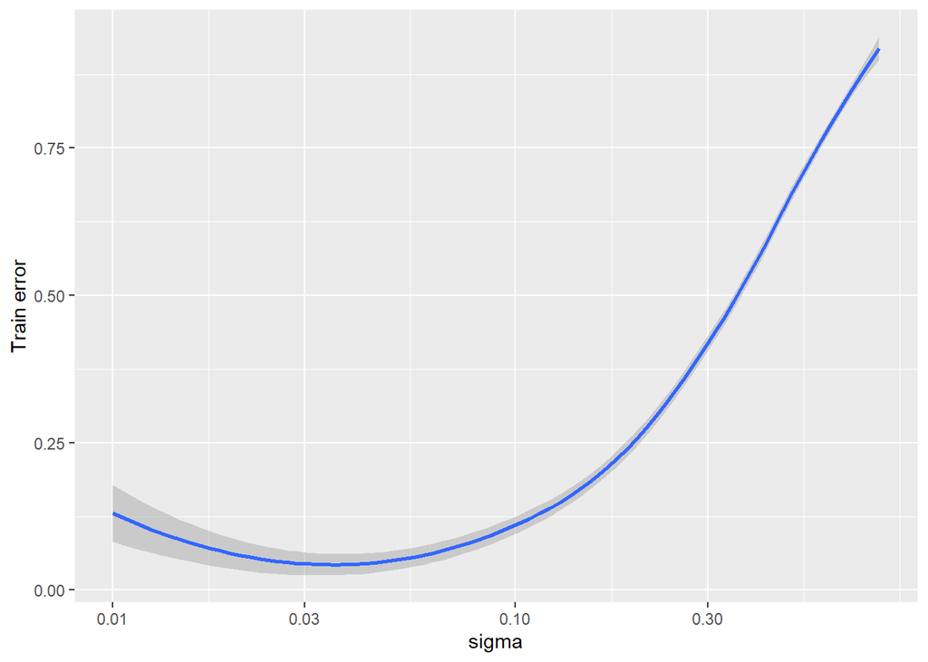

```r
univat_plot <- ggplot(data = ridge_results_df_2,aes(x=sigma,y=train_error)) + geom_smooth() +
  scale_x_continuous(trans='log10') +
  labs(x='sigma',y='Train error')
univat_plot
```

#### **Validate error graph**

In the validate error graph, we can see a bigger influence of regularisation. By damaging our performance in training data, our model can produce better results with the proper value of sigma. As the hyperparameter sigma rises the mean squared error on the validation data falls between the values 0.01 an 0.10 before rising again.

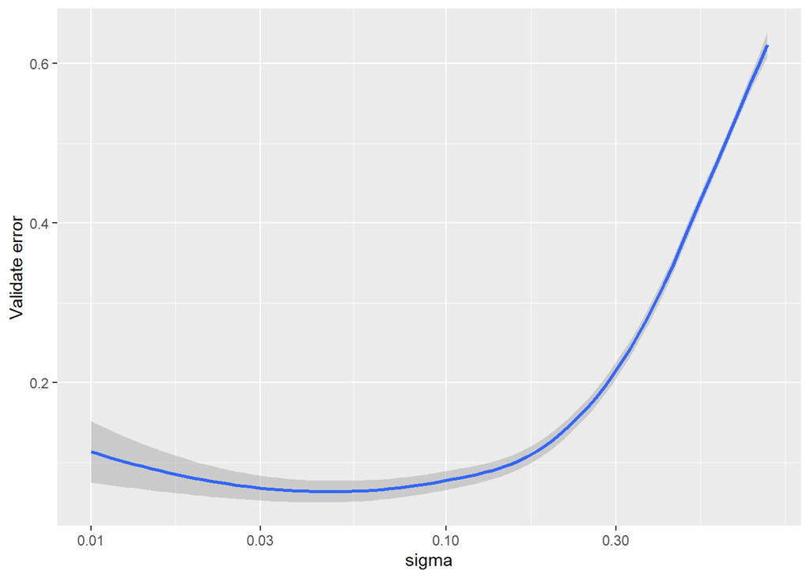

```r
univat_plot <- ggplot(data = ridge_results_df_2,aes(x=sigma,y=validate_error)) + geom_smooth() +
  scale_x_continuous(trans='log10') +
  labs(x='sigma',y='Validate error')
univat_plot
```

## **Ridge regression performance on test data**

#### **Determine the hyper-parameter σ with the lowest validation error**

```r
#Find minimum validation error
min_validation_error <- ridge_results_df_2 %>%
  pull(validate_error) %>% min()

#Find the corresponding hyper-parameter.
optimal_sigma <- ridge_results_df_2 %>%
  filter(validate_error == min_validation_error) %>%
  pull(sigma)
```

#### **Retrain the ridge regression model with the selected value of the hyper-parameter σ and estimate the **test error** by computing the mean squared error on the test data.**

```r
d<-players_train_x %>% ncol()
rand_weights_matrix <- matrix(rnorm(num_random_features*d,sd=optimal_sigma),ncol=d)
rand_bias <- runif(num_random_features,max = (2*pi))

final_train_z <- random_feature_transform(players_train_x,rand_weights_matrix,rand_bias)
final_test_z <- random_feature_transform(players_test_x,rand_weights_matrix,rand_bias)

#Extract the ridge regression model with the optimal hyper-parameter.
final_ridge_model <- glmnet(x=final_train_z,y=players_train_y,alpha = 0,lambda = optimal_lambda,family="gaussian")

#Use the test data to estimate the out-of-sample performance of the trained model.
final_ridge_test_y_est <- predict(final_ridge_model,newx=final_test_z) #test predictions
final_ridge_test_error <- mean((players_test_y-final_ridge_test_y_est)^2) #test error
```

```r
final_ridge_test_error
```

```
## [1] 0.07865481
```

## **References**

[1] Sunil RayI am a Business Analytics and Intelligence professional with deep experience in the Indian Insurance industry. I have worked for various multi-national Insurance companies in last 7 years. (2020, October 18). Regression Techniques in Machine Learning. Retrieved from https://www.analyticsvidhya.com/blog/2015/08/comprehensive-guide-regression/

[2] Leone, S. (2019, September 26). FIFA 20 complete player dataset. Retrieved from https://www.kaggle.com/stefanoleone992/fifa-20-complete-player-dataset

[3] NCSS Statistical Software, Ridge Regression Chapter 335. Retrieved from https://ncss-wpengine.netdna-ssl.com/wp-content/themes/ncss/pdf/Procedures/NCSS/Ridge_Regression.pdf

[4] Team, T. A. (2020, May 29). How, When, and Why Should You Normalize / Standardize / Rescale Your Data? Retrieved from https://towardsai.net/p/data-science/how-when-and-why-should-you-normalize-standardize-rescale-your-data-3f083def38ff